# Exploratory analysis: gender and cognitive competence

### Attatching packages

```r
library(readr)
library(tidyverse)
load(url("http://www.rossmanchance.com/iscam3/ISCAM.RData"))
```

### Loading in data

```r
allYrsFinal <- read_csv("FinalFiles2023/Data/All Years Final Public - with Vars.csv")
```

### Gender and Pre iscamboxplot

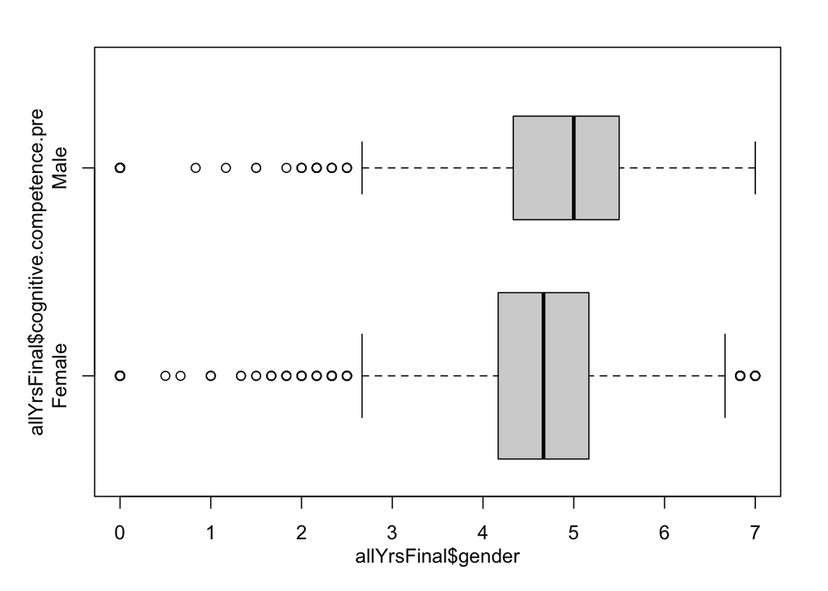

```r
iscamboxplot(allYrsFinal$cognitive.competence.pre, explanatory=allYrsFinal$gender)
```

### Gender and Pre violin + boxplot

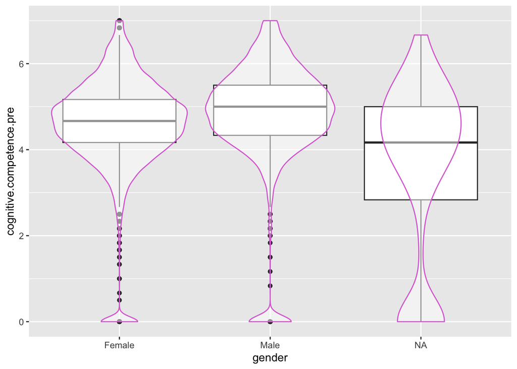

```r
#cognitive.competence.pre   cognitive.competence.post
#cognitive.competence.change
# gender
allYrsFinal|>
  #filter(!is.na(gender), !is.na(cognitive.competence.pre)) |>
  ggplot(aes(x=gender, y=cognitive.competence.pre)) +
  geom_boxplot() + geom_violin(alpha = 0.5, color = "orchid")
```

### Gender and Pre t-test

```r
t.test(allYrsFinal$cognitive.competence.pre ~ allYrsFinal$gender)
```

```
    Welch Two Sample t-test

data:  allYrsFinal$cognitive.competence.pre by allYrsFinal$gender
t = -8.9969, df = 10761, p-value < 2.2e-16
alternative hypothesis: true difference in means between group Female and group Male is not equal to 0
95 percent confidence interval:
 -0.2446798 -0.1571351
sample estimates:
mean in group Female   mean in group Male
            4.552662             4.753569
```

### Gender and Post iscamboxplot

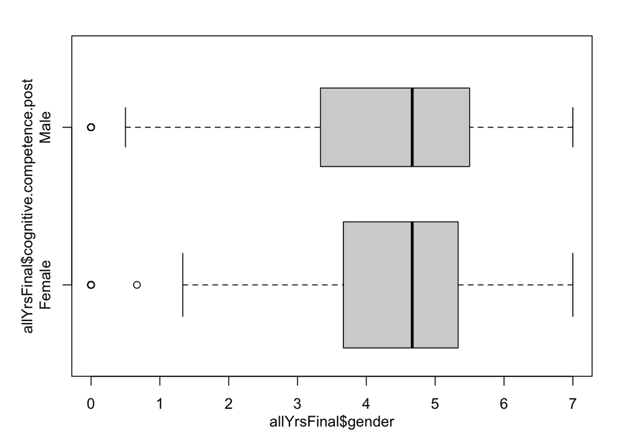

```r
iscamboxplot(allYrsFinal$cognitive.competence.post, explanatory=allYrsFinal$gender)
```

### Gender and Post violin + boxplot

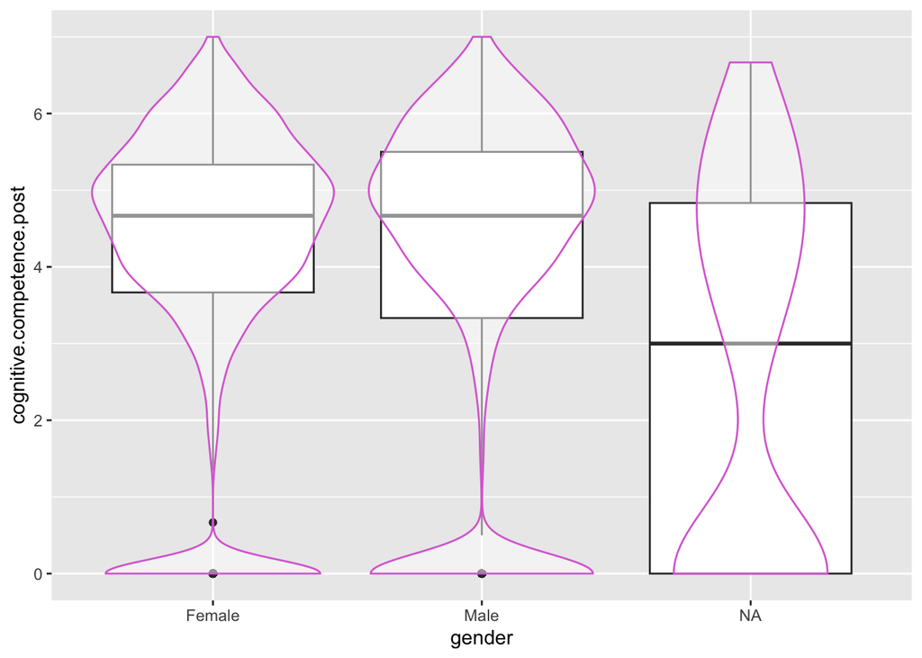

```r
allYrsFinal|>
  #filter(!is.na(gender), !is.na(cognitive.competence.post)) |>
  ggplot(aes(x=gender, y=cognitive.competence.post)) +
  geom_boxplot() + geom_violin(alpha = 0.5, color="orchid")
```

### Gender and Post t-test

```r
t.test(allYrsFinal$cognitive.competence.post ~ allYrsFinal$gender)
```

```
    Welch Two Sample t-test

data:  allYrsFinal$cognitive.competence.post by allYrsFinal$gender
t = 4.5054, df = 10669, p-value = 6.694e-06
alternative hypothesis: true difference in means between group Female and group Male is not equal to 0
95 percent confidence interval:
 0.08931763 0.22689092
sample estimates:
mean in group Female   mean in group Male
            4.090780             3.932676
```

### Gender and Change iscamboxplot

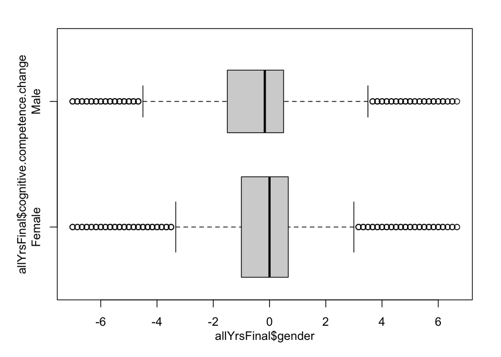

```r
iscamboxplot(allYrsFinal$cognitive.competence.change, explanatory=allYrsFinal$gender)
```

### Gender and Change boxplot

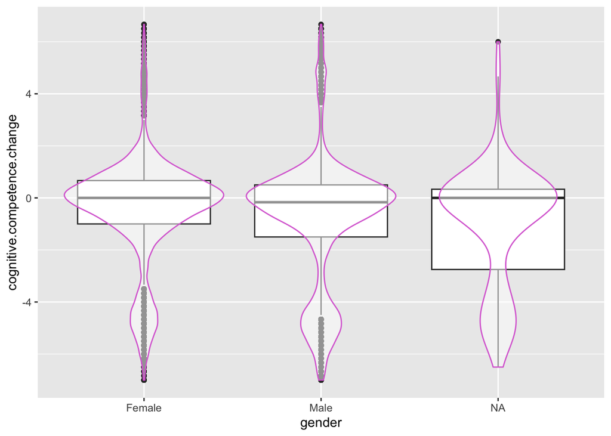

```r
allYrsFinal|>
  #filter(!is.na(gender), !is.na(cognitive.competence.change)) |>
  ggplot(aes(x=gender, y=cognitive.competence.change)) +
  geom_boxplot() + geom_violin(alpha = 0.5, color = "orchid")
```

### Gender and Change t-test

```r
t.test(allYrsFinal$cognitive.competence.change ~ allYrsFinal$gender)
```

```
    Welch Two Sample t-test

data:  allYrsFinal$cognitive.competence.change by allYrsFinal$gender
t = 8.9447, df = 10392, p-value < 2.2e-16
alternative hypothesis: true difference in means between group Female and group Male is not equal to 0
95 percent confidence interval:
 0.2803360 0.4376874
sample estimates:
mean in group Female   mean in group Male
          -0.4618816           -0.8208933
```

## By Question t-tests

Post:

- 6e: I had trouble understanding statistics because of how I think.
- 7a: I had no idea of what was going on in this statistics course.
- 8f: I made a lot of math errors in statistics.
- 9a: I learned statistics.
- 9b: I understood statistics equations.
- 9e: I found it difficult to understand statistical concepts.

t-tests per question:

```r
competence <- c("^q6e", "^q7a", "^q8f", "^q9a", "^q9b", "^q9e")

t_test_results <- list()

for (pattern in competence) {
  matched_columns <- grep(pattern, colnames(allYrsFinal), value = TRUE)

  for (column in matched_columns) {
    t_test_result <- t.test(allYrsFinal[[column]] ~ allYrsFinal$gender)

    t_test_results[[column]] <- t_test_result
  }
}
t_test_results
```

```
$q6e.pre.a

    Welch Two Sample t-test

data:  allYrsFinal[[column]] by allYrsFinal$gender
t = -21.683, df = 11177, p-value < 2.2e-16
alternative hypothesis: true difference in means between group Female and group Male is not equal to 0
95 percent confidence interval:
 -0.5213980 -0.4349444
sample estimates:
mean in group Female   mean in group Male
            4.344519             4.822690


$q6e.post.a

    Welch Two Sample t-test

data:  allYrsFinal[[column]] by allYrsFinal$gender
t = -14.687, df = 9381.7, p-value < 2.2e-16
alternative hypothesis: true difference in means between group Female and group Male is not equal to 0
95 percent confidence interval:
 -0.4705743 -0.3597528
sample estimates:
mean in group Female   mean in group Male
            4.381603             4.796766


$q7a.pre.a

    Welch Two Sample t-test

data:  allYrsFinal[[column]] by allYrsFinal$gender
t = -11.725, df = 11559, p-value < 2.2e-16
alternative hypothesis: true difference in means between group Female and group Male is not equal to 0
95 percent confidence interval:
 -0.2807990 -0.2003607
sample estimates:
mean in group Female   mean in group Male
            4.980599             5.221179
```

[output cut: 111 more lines]

```
            4.091359             4.494541


$q9e.post.a

    Welch Two Sample t-test

data:  allYrsFinal[[column]] by allYrsFinal$gender
t = -11.239, df = 9448.2, p-value < 2.2e-16
alternative hypothesis: true difference in means between group Female and group Male is not equal to 0
95 percent confidence interval:
 -0.3423140 -0.2406415
sample estimates:
mean in group Female   mean in group Male
            4.222667             4.514145
```

## Per Question Visuals

```r
competenceFull <- c("q6e.pre.a", "q6e.post.a", "q7a.pre.a", "q7a.post.a", "q8f.pre.a", "q8f.post.a", "q9a.pre.a", "q9a.post.a", "q9b.pre.a", "q9b.post.a", "q9e.pre.a", "q9e.post.a")

questions_long <- allYrsFinal |>
  select(all_of(competenceFull), gender) |>
  pivot_longer(cols=all_of(competenceFull),
               names_to = "question",
               values_to = "score")
```

Pre Questions By Gender Boxplots

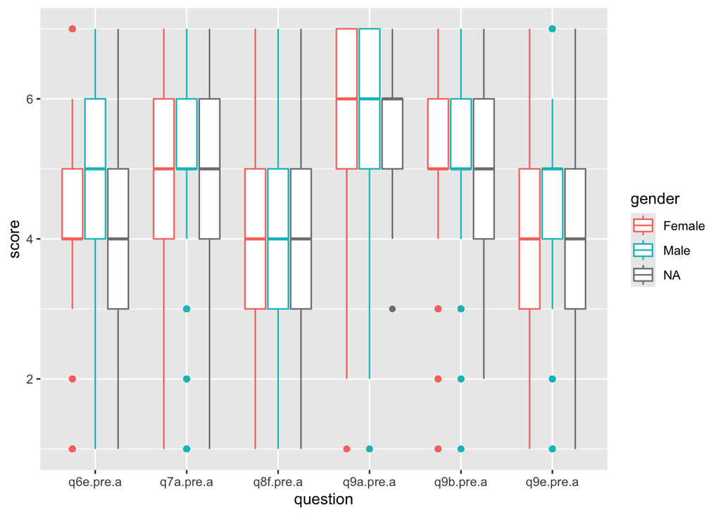

```r
questions_long|>
  group_by(gender)|>
  filter(str_detect(question, "pre")) |>
  ggplot(aes(x=question, y = score, color = gender)) + geom_boxplot()
```

Post Questions by Gender Boxplots

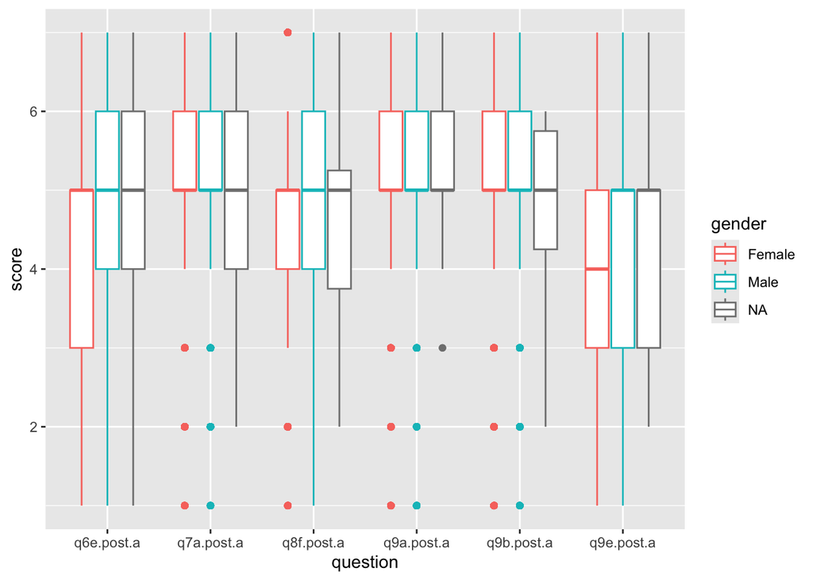

```r
questions_long|>
  group_by(gender)|>
  filter(str_detect(question, "post")) |>
  ggplot(aes(x=question, y = score, color = gender)) + geom_boxplot()
```

Pre vs. Post Faceted by Gender

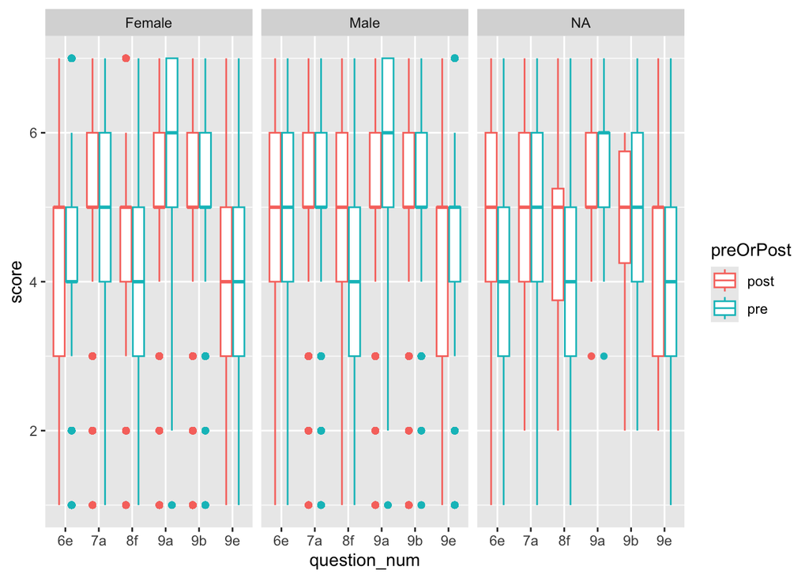

```r
questions_long <- questions_long |>
  mutate(preOrPost = case_when(str_detect(question, "pre") ~ "pre",
                               str_detect(question, "post") ~ "post"),
         question_num = str_extract(question, "q\\d+[a-z]"))

questions_long|>
  group_by(preOrPost) |>
  ggplot(aes(x=question_num, y= score, color = preOrPost)) +
  geom_boxplot() +
  facet_grid(.~gender) +
  scale_x_discrete(labels = function(x) str_extract(x, "\\d+[a-z]"))
```

Change Per Question by Gender

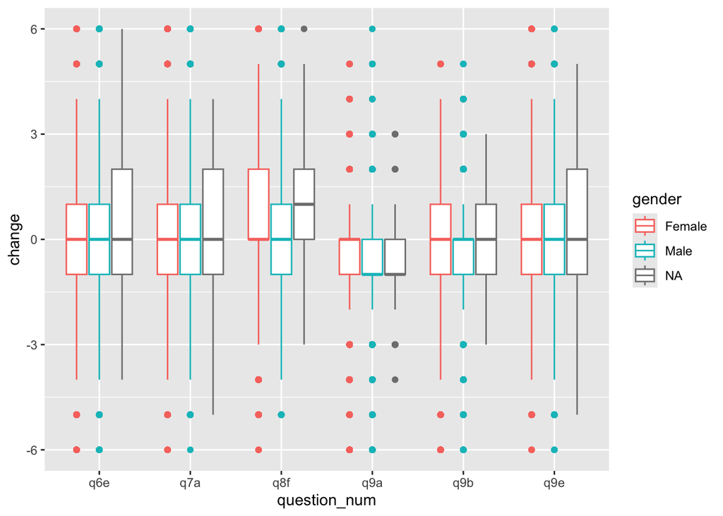

```r
questions_long <- questions_long |>
  mutate(row_id = row_number())

questions_wide <- questions_long |>
  pivot_wider(names_from = preOrPost, values_from = score, id_cols = c(row_id, gender, question_num)) |>
  select(-row_id) |>
  group_by(gender, question_num) |>
  fill(pre, post, .direction = "downup") |>
  ungroup()

questions_change <- questions_wide |>
  mutate(change = post - pre)

questions_change|>
  ggplot(aes(x=question_num, y=change, color = gender)) + geom_boxplot()
```

## Where there are “other” or “don’t want to answer” for the gender question

```r
unique(allYrsFinal$gender)
```

```
[1] "Female" "Male"   NA
```

```r
allYrsFinal|>
  filter(is.na(gender))
```

```
# A tibble: 123 × 297
   instructor  section instructor.section opt.out.pre opt.out.post test.time.pre
   <chr>         <dbl> <chr>                    <dbl>        <dbl>         <dbl>
 1 Instructor2       1 Instructor2_Secti…           1           NA            16
 2 Instructor3       2 Instructor3_Secti…           1            1            28
 3 Instructor4       3 Instructor4_Secti…           1            1            62
 4 Instructor4       4 Instructor4_Secti…           1            1            24
 5 Instructor5       1 Instructor5_Secti…           1           NA            11
 6 Instructor8       1 Instructor8_Secti…           1           NA            12
 7 Instructor8       1 Instructor8_Secti…           1           NA          2777
 8 Instructor…       1 Instructor11_Sect…           1            1            33
 9 Instructor…       1 Instructor11_Sect…           1           NA            22
10 Instructor…       1 Instructor11_Sect…           1            1            27
# ℹ 113 more rows
# ℹ 291 more variables: test.time.post <dbl>, q16a.pre.c.1415 <chr>,
#   q16b.pre.c.1415 <chr>, q16c.pre.c.1415 <chr>, q16a.pre.c <chr>,
#   q16b.pre.c <chr>, q16c.pre.c <chr>, q16d.pre.c <chr>, q16.pre.c <dbl>,
#   q17.pre.c <chr>, q18.pre.c <chr>, q19.pre.c <chr>, q20.pre.c <chr>,
#   q21.pre.c <chr>, q22.pre.c <chr>, q23.pre.c <chr>, q24.pre.c <chr>,
#   q25.pre.c <chr>, q26.pre.c <chr>, q27.pre.c <chr>, q28.pre.c <chr>, …
```

### Mean pre cog comp by gender

```r
# note: NAs have the lowest pre and post cognitive competence, and have the greatest decrease in cognitive competence
allYrsFinal|>
  group_by(gender)|>
  summarize(mean(cognitive.competence.pre))
```

```
# A tibble: 3 × 2
  gender `mean(cognitive.competence.pre)`
  <chr>                             <dbl>
1 Female                             4.55
2 Male                               4.75
3 <NA>                               3.53
```

### Mean post cog comp by gender

```r
allYrsFinal|>
  group_by(gender)|>
  summarize(mean(cognitive.competence.post))
```

```
# A tibble: 3 × 2
  gender `mean(cognitive.competence.post)`
  <chr>                              <dbl>
1 Female                              4.09
2 Male                                3.93
3 <NA>                                2.52
```

### Mean change cog comp by gender

```r
allYrsFinal|>
  group_by(gender)|>
  summarize(mean(cognitive.competence.change))
```

```
# A tibble: 3 × 2
  gender `mean(cognitive.competence.change)`
  <chr>                                <dbl>
1 Female                              -0.462
2 Male                                -0.821
3 <NA>                                -1.01
```

### How much do individual questions differ in terms of mean female - mean male to other ones within cog comp?

```r
competence <- c("^q6e", "^q7a", "^q8f", "^q9a", "^q9b", "^q9e")
competenceFull <- c("q6e.pre.a", "q6e.post.a", "q7a.pre.a", "q7a.post.a", "q8f.pre.a", "q8f.post.a", "q9a.pre.a", "q9a.post.a", "q9b.pre.a", "q9b.post.a", "q9e.pre.a", "q9e.post.a")
#competenceFull
qDiffsGender <- list()
for (q in competenceFull) {
  q <- sym(q)
  question <- allYrsFinal|>
    group_by(gender)|>
    filter(!is.na(!!q))|>
    summarize(mean(!!q))
  qDiffsGender[[q]] <- question[[1,2]] - question[[2,2]]
}

#questionDiffs

qDiffsGender_df <- enframe(unlist(qDiffsGender), name = "question", value = "diff")
qDiffsGender_df
```

```
# A tibble: 12 × 2
   question      diff
   <chr>        <dbl>
 1 q6e.pre.a  -0.478
 2 q6e.post.a -0.415
 3 q7a.pre.a  -0.241
 4 q7a.post.a -0.201
 5 q8f.pre.a  -0.184
 6 q8f.post.a -0.0704
 7 q9a.pre.a  -0.192
 8 q9a.post.a -0.0764
 9 q9b.pre.a  -0.280
10 q9b.post.a -0.144
11 q9e.pre.a  -0.403
12 q9e.post.a -0.291
```

## “Max Possible Score” on cogcomp.pre

overall max : 7

```r
max(allYrsFinal$cognitive.competence.pre)
```

```
[1] 7
```

## Is change in attitude is a better predictor of achievable than the actual attitude?

Change in attitude * change in attitudes is a significant predictor of achievable gain * adj R^2 = 0.01189 * rmse = 0.2702

```r
change_ach.fit <- lm(ach.gain.24 ~ cognitive.competence.change, data = allYrsFinal)

summary(change_ach.fit)
```

```
Call:
lm(formula = ach.gain.24 ~ cognitive.competence.change, data = allYrsFinal)

Residuals:
    Min      1Q  Median      3Q     Max
-3.7634 -0.1529  0.0128  0.1744  0.8665

Coefficients:
                            Estimate Std. Error t value Pr(>|t|)
(Intercept)                 0.143191   0.002488   57.56   <2e-16 ***
cognitive.competence.change 0.029044   0.002429   11.96   <2e-16 ***
---
Signif. codes:  0 '***' 0.001 '**' 0.01 '*' 0.05 '.' 0.1 ' ' 1

Residual standard error: 0.2702 on 11797 degrees of freedom
  (2993 observations deleted due to missingness)
Multiple R-squared:  0.01198,   Adjusted R-squared:  0.01189
F-statistic:   143 on 1 and 11797 DF,  p-value: < 2.2e-16
```

Actual attitude (pre) * pre-attitudes in cognitive competence is a statistically significant predictor of achievable gain * adj R^2 = 0.00676 * rmse = 0.2709

```r
pre_ach.fit <- lm(ach.gain.24 ~ cognitive.competence.pre, data = allYrsFinal)

summary(pre_ach.fit)
```

```
Call:
lm(formula = ach.gain.24 ~ cognitive.competence.pre, data = allYrsFinal)

Residuals:
    Min      1Q  Median      3Q     Max
-3.7893 -0.1528  0.0155  0.1751  0.8610

Coefficients:
                         Estimate Std. Error t value Pr(>|t|)
(Intercept)              0.020855   0.013765   1.515     0.13
cognitive.competence.pre 0.025322   0.002808   9.017   <2e-16 ***
---
Signif. codes:  0 '***' 0.001 '**' 0.01 '*' 0.05 '.' 0.1 ' ' 1

Residual standard error: 0.2709 on 11797 degrees of freedom
  (2993 observations deleted due to missingness)
Multiple R-squared:  0.006844,  Adjusted R-squared:  0.00676
F-statistic:  81.3 on 1 and 11797 DF,  p-value: < 2.2e-16
```

Actual attitude (post) * post attitudes in cognitive competence are a significant predictor of achievable gain * adj R^2 = 0.03201 * rmse = 0.2674

```r
post_ach.fit <- lm(ach.gain.24 ~ cognitive.competence.post, data = allYrsFinal)

summary(post_ach.fit)
```

```
Call:
lm(formula = ach.gain.24 ~ cognitive.competence.post, data = allYrsFinal)

Residuals:
    Min      1Q  Median      3Q     Max
-3.8003 -0.1519  0.0183  0.1735  0.9216

Coefficients:
                           Estimate Std. Error t value Pr(>|t|)
(Intercept)               -0.083240   0.011697  -7.116 1.17e-12 ***
cognitive.competence.post  0.047009   0.002377  19.777  < 2e-16 ***
---
Signif. codes:  0 '***' 0.001 '**' 0.01 '*' 0.05 '.' 0.1 ' ' 1

Residual standard error: 0.2674 on 11797 degrees of freedom
  (2993 observations deleted due to missingness)
Multiple R-squared:  0.03209,   Adjusted R-squared:  0.03201
F-statistic: 391.1 on 1 and 11797 DF,  p-value: < 2.2e-16
```

Actual attitude (pre AND post) * model with pre and post attitudes in cognitive competence is a significant predictor of achievable gain * adj R^2 = 0.03194 * rmse = 0.2675

```r
pre_post_ach.fit <- lm(ach.gain.24 ~ cognitive.competence.post + cognitive.competence.pre, data = allYrsFinal)

summary(pre_post_ach.fit)
```

```
Call:
lm(formula = ach.gain.24 ~ cognitive.competence.post + cognitive.competence.pre,
    data = allYrsFinal)

Residuals:
    Min      1Q  Median      3Q     Max
-3.8011 -0.1520  0.0185  0.1731  0.9193

Coefficients:
                           Estimate Std. Error t value Pr(>|t|)
(Intercept)               -0.087352   0.014923  -5.853 4.95e-09 ***
cognitive.competence.post  0.046489   0.002649  17.547  < 2e-16 ***
cognitive.competence.pre   0.001371   0.003090   0.444    0.657
---
Signif. codes:  0 '***' 0.001 '**' 0.01 '*' 0.05 '.' 0.1 ' ' 1

Residual standard error: 0.2675 on 11796 degrees of freedom
  (2993 observations deleted due to missingness)
Multiple R-squared:  0.03211,   Adjusted R-squared:  0.03194
F-statistic: 195.7 on 2 and 11796 DF,  p-value: < 2.2e-16
```

### Comparing the models

Post-attitudes have the lowest AIC and BIC (best predictor)

```r
AIC(change_ach.fit, pre_ach.fit, post_ach.fit, pre_post_ach.fit)
```

```
                 df      AIC
change_ach.fit    3 2608.822
pre_ach.fit       3 2669.961
post_ach.fit      3 2366.140
pre_post_ach.fit  4 2367.943
```

```r
BIC(change_ach.fit, pre_ach.fit, post_ach.fit, pre_post_ach.fit)
```

```
                 df      BIC
change_ach.fit    3 2630.949
pre_ach.fit       3 2692.089
post_ach.fit      3 2388.267
pre_post_ach.fit  4 2397.446
```

## Interactions

With post-attitude as the response

- cognitive.competence.pre:cognitive.competence.change not significant

```r
# lm(y~x1+x2+x1:x2, data=my.data)
post_int.fit <- lm(cognitive.competence.post ~ cognitive.competence.pre+cognitive.competence.change + cognitive.competence.pre:cognitive.competence.change, data = allYrsFinal)

summary(post_int.fit)
```

```
Call:
lm(formula = cognitive.competence.post ~ cognitive.competence.pre +
    cognitive.competence.change + cognitive.competence.pre:cognitive.competence.change,
    data = allYrsFinal)

Residuals:
       Min         1Q     Median         3Q        Max
-1.400e-14 -3.600e-15 -1.200e-15  8.000e-16  9.744e-12

Coefficients:
                                                      Estimate Std. Error
(Intercept)                                          3.674e-13  4.432e-15
cognitive.competence.pre                             1.000e+00  9.239e-16
cognitive.competence.change                          1.000e+00  1.155e-15
cognitive.competence.pre:cognitive.competence.change 2.310e-16  2.325e-16
                                                       t value Pr(>|t|)
(Intercept)                                          8.289e+01   <2e-16 ***
cognitive.competence.pre                             1.082e+15   <2e-16 ***
cognitive.competence.change                          8.655e+14   <2e-16 ***
cognitive.competence.pre:cognitive.competence.change 9.940e-01     0.32
---
Signif. codes:  0 '***' 0.001 '**' 0.01 '*' 0.05 '.' 0.1 ' ' 1

Residual standard error: 1.118e-13 on 14788 degrees of freedom
Multiple R-squared:      1, Adjusted R-squared:      1
F-statistic: 1.594e+30 on 3 and 14788 DF,  p-value: < 2.2e-16
```

With achievable gain as the response

- cognitive.competence.pre:cognitive.competence.change not significant

```r
# lm(y~x1+x2+x1:x2, data=my.data)
ach_int1.fit <- lm(ach.gain.24 ~ cognitive.competence.pre+cognitive.competence.change + cognitive.competence.pre:cognitive.competence.change, data = allYrsFinal)

summary(ach_int1.fit)
```

```
Call:
lm(formula = ach.gain.24 ~ cognitive.competence.pre + cognitive.competence.change +
    cognitive.competence.pre:cognitive.competence.change, data = allYrsFinal)

Residuals:
    Min      1Q  Median      3Q     Max
-3.8012 -0.1524  0.0182  0.1733  0.9193

Coefficients:
                                                      Estimate Std. Error
(Intercept)                                          -0.090560   0.015188
cognitive.competence.pre                              0.048372   0.003089
cognitive.competence.change                           0.055302   0.008192
cognitive.competence.pre:cognitive.competence.change -0.001929   0.001697
                                                     t value Pr(>|t|)
(Intercept)                                           -5.963 2.55e-09 ***
cognitive.competence.pre                              15.662  < 2e-16 ***
cognitive.competence.change                            6.751 1.54e-11 ***
cognitive.competence.pre:cognitive.competence.change  -1.137    0.256
---
Signif. codes:  0 '***' 0.001 '**' 0.01 '*' 0.05 '.' 0.1 ' ' 1

Residual standard error: 0.2675 on 11795 degrees of freedom
  (2993 observations deleted due to missingness)
Multiple R-squared:  0.03221,   Adjusted R-squared:  0.03197
F-statistic: 130.9 on 3 and 11795 DF,  p-value: < 2.2e-16
```